# Data Cleaning Using Messy Fifa21 Data

## Introduction

This dataset is obtained from Kagle and the data was originally scraped from a website which made it messy, the data contains the name, photo URL, player URL, nationality, position, age, etc.

The dataset has the following problems:

- wrong data types
- newline characters in some columns
- remove some characters and change their data types
- Some players are high-valued and still underpaid
- Missing values
- outliers
- wrong record format

```python
# load the pandas library
import pandas as pd
import warnings
```

```python
# import the data set
data = pd.read_csv("D:/data/fifa21_raw_data.csv", low_memory = False)
```

```python
# view the dataset
data.head()
```

|  | photoUrl | LongName | playerUrl | Nationality | Positions | Name | Age | ↓OVA | POT | Team & Contract | ... | A/W | D/W | IR | PAC | SHO | PAS | DRI | DEF | PHY | Hits |
| --- | --- | --- | --- | --- | --- | --- | --- | --- | --- | --- | --- | --- | --- | --- | --- | --- | --- | --- | --- | --- | --- |
| 0 | https://cdn.sofifa.com/players/158/023/21_60.png | Lionel Messi | http://sofifa.com/player/158023/lionel-messi/2... | Argentina | RW ST CF | L. Messi | 33 | 93 | 93 | \n\n\n\nFC Barcelona\n2004 ~ 2021\n\n | ... | Medium | Low | 5 ★ | 85 | 92 | 91 | 95 | 38 | 65 | \n372 |
| 1 | https://cdn.sofifa.com/players/020/801/21_60.png | C. Ronaldo dos Santos Aveiro | http://sofifa.com/player/20801/c-ronaldo-dos-s... | Portugal | ST LW | Cristiano Ronaldo | 35 | 92 | 92 | \n\n\n\nJuventus\n2018 ~ 2022\n\n | ... | High | Low | 5 ★ | 89 | 93 | 81 | 89 | 35 | 77 | \n344 |
| 2 | https://cdn.sofifa.com/players/200/389/21_60.png | Jan Oblak | http://sofifa.com/player/200389/jan-oblak/210005/ | Slovenia | GK | J. Oblak | 27 | 91 | 93 | \n\n\n\nAtlético Madrid\n2014 ~ 2023\n\n | ... | Medium | Medium | 3 ★ | 87 | 92 | 78 | 90 | 52 | 90 | \n86 |
| 3 | https://cdn.sofifa.com/players/192/985/21_60.png | Kevin De Bruyne | http://sofifa.com/player/192985/kevin-de-bruyn... | Belgium | CAM CM | K. De Bruyne | 29 | 91 | 91 | \n\n\n\nManchester City\n2015 ~ 2023\n\n | ... | High | High | 4 ★ | 76 | 86 | 93 | 88 | 64 | 78 | \n163 |
| 4 | https://cdn.sofifa.com/players/190/871/21_60.png | Neymar da Silva Santos Jr. | http://sofifa.com/player/190871/neymar-da-silv... | Brazil | LW CAM | Neymar Jr | 28 | 91 | 91 | \n\n\n\nParis Saint-Germain\n2017 ~ 2022\n\n | ... | High | Medium | 5 ★ | 91 | 85 | 86 | 94 | 36 | 59 | \n273 |

5 rows × 77 columns

```python
# convert to a pandas dataframe
data = pd.DataFrame(data)
```

```python
# number of columns and row
rows, columns = data.shape
print(f"Number of Rows: {rows}")
print(f"Number of Columns: {columns}")
```

```
Number of Rows: 18979
Number of Columns: 77
```

This data has about 18979 observations and 77 columns

```python
data.info()
```

```
<class 'pandas.core.frame.DataFrame'>
RangeIndex: 18979 entries, 0 to 18978
Data columns (total 77 columns):
 #   Column            Non-Null Count  Dtype
---  ------            --------------  -----
 0   photoUrl          18979 non-null  object
 1   LongName          18979 non-null  object
 2   playerUrl         18979 non-null  object
 3   Nationality       18979 non-null  object
 4   Positions         18979 non-null  object
 5   Name              18979 non-null  object
 6   Age               18979 non-null  int64
 7   ↓OVA              18979 non-null  int64
 8   POT               18979 non-null  int64
 9   Team & Contract   18979 non-null  object
```

[output cut: 69 more lines]

From the result we can see that some of the variables are not in their right data type and also there are no missing values in the data set.  
I will convert some of the variables to theire right data types

#### Select columns that need to cleaned

```python
data = data[['Wage', 'Value', 'Name', 'playerUrl','LongName', 'photoUrl' ,'Age','Height','Nationality' ]]
```

##### Convert some of the columns to the right data type

```python
data=data.astype({'photoUrl':'string', 'LongName':'string', 'playerUrl':'string', 'Nationality':'string',  'Name':'string','Value':'string','Wage':'string' })
data.info()
```

```
<class 'pandas.core.frame.DataFrame'>
RangeIndex: 18979 entries, 0 to 18978
Data columns (total 9 columns):
 #   Column       Non-Null Count  Dtype
---  ------       --------------  -----
 0   Wage         18979 non-null  string
 1   Value        18979 non-null  string
 2   Name         18979 non-null  string
 3   playerUrl    18979 non-null  string
 4   LongName     18979 non-null  string
 5   photoUrl     18979 non-null  string
 6   Age          18979 non-null  int64
 7   Height       18979 non-null  object
 8   Nationality  18979 non-null  string
dtypes: int64(1), object(1), string(7)
memory usage: 1.3+ MB
```

### String Manipulation

The height variable contains the quotation character ""' which is not useful for analysis, this quotation were removed and the variable was converted to numeric data type

```python
data['Height'] = data['Height'].str.replace("'", ".").str.replace('"','')

data['Height'] = pd.to_numeric(data['Height'], errors='coerce')
```

```python
print(data['Height'])
```

```
0        5.70
1        6.20
2        6.20
3        5.11
4        5.90
         ...
18974    5.10
18975    5.70
18976    5.10
18977    5.90
18978    5.90
Name: Height, Length: 18979, dtype: float64
```

#### Delete string characters from numbers

```python
data['Value'] = data['Value'].str[1:-1]
```

```python
print(data['Value'])
```

```
0        67.5
1          46
2          75
3          87
4          90
         ...
18974      35
18975      60
18976      40
18977      60
18978      60
Name: Value, Length: 18979, dtype: string
```

```python
data['Wage'] = data['Wage'].str[1:-1]
```

```python
print(data['Wage'])
```

```
0        560
1        220
2        125
3        370
4        270
        ...
18974      1
18975     50
18976      1
18977     50
18978     50
Name: Wage, Length: 18979, dtype: string
```

```python
data['Wage'] = pd.to_numeric(data['Wage'], errors='coerce')
```

```python
data['Value'] = pd.to_numeric(data['Value'], errors='coerce')
```

### View the dataset

```python
data.info()
```

```
<class 'pandas.core.frame.DataFrame'>
RangeIndex: 18979 entries, 0 to 18978
Data columns (total 9 columns):
 #   Column       Non-Null Count  Dtype
---  ------       --------------  -----
 0   Wage         18741 non-null  Float64
 1   Value        18730 non-null  Float64
 2   Name         18979 non-null  string
 3   playerUrl    18979 non-null  string
 4   LongName     18979 non-null  string
 5   photoUrl     18979 non-null  string
 6   Age          18979 non-null  int64
 7   Height       18979 non-null  float64
 8   Nationality  18979 non-null  string
dtypes: Float64(2), float64(1), int64(1), string(5)
memory usage: 1.3 MB
```

### Check for missing values

```python
print(data.isnull().sum())
```

```
Wage           238
Value          249
Name             0
playerUrl        0
LongName         0
photoUrl         0
Age              0
Height           0
Nationality      0
dtype: int64
```

From the result above, it is shown that there are 238 missing values for player's wages and 249 missing values for players values

### Handling Missing values

There are different methods in handling missing values such as:

- Drop rows
- Filling Missing Values
- Linear interpolation
- Using Forward Fill or Backward Fill
- k-Nearest Neighbors (KNN) Imputation
- predictive Modeling

For this study I will be handling missing values by dropping the rows

```python
a= data.dropna()
print(a)

data = a
```

```
        Wage  Value               Name  \
0      560.0   67.5           L. Messi
1      220.0   46.0  Cristiano Ronaldo
2      125.0   75.0           J. Oblak
3      370.0   87.0       K. De Bruyne
4      270.0   90.0          Neymar Jr
...      ...    ...                ...
18974    1.0   35.0     Zhang Mengxuan
18975   50.0   60.0        V. Da Silva
18976    1.0   40.0             Xia Ao
18977   50.0   60.0           B. Hough
18978   50.0   60.0          M. Flores

                                               playerUrl  \
0      http://sofifa.com/player/158023/lionel-messi/2...
```

[output cut: 51 more lines]

## Feature Engineering

I want to get the year of birth from the age of players

```python
from datetime import date

def calculate_year_of_birth(age):
    current_year = date.today().year
    year_of_birth = current_year-age
    return year_of_birth
```

```python
data['year_of_birth'] = calculate_year_of_birth(data['Age'])
data=data.astype({'year_of_birth':'string'})
```

```python
print(data['year_of_birth'])
```

```
0        1991
1        1989
2        1997
3        1995
4        1996
         ...
18974    2003
18975    2007
18976    2003
18977    2007
18978    2005
Name: year_of_birth, Length: 18730, dtype: string
```

### Check and remove duplicates in Name column

```python
a=data['Name'] = data['Name'].duplicated()
print(a)
```

[output not shown]

From the result, there are no duplicate name records

### Check for Outliers Using Z-Score Method

```python
import numpy as np
from scipy import stats
```

```python
Z_Scores_name = np.abs(stats.zscore(data['Wage']))
outliers_name = Z_Scores_name >3
print(f"There are {outliers_name.sum()} outliers in players value record")
Z_Scores_Value = np.abs(stats.zscore(data['Value']))
outliers_Value = Z_Scores_Value >3
print(f"There are {outliers_Value.sum()} outliers in Players wage record")
```

```
There are 131 outliers in players value record
There are 0 outliers in Players wage record
```

### Handling Outliers

##### There are different methods used to handle outliers, this methods are:

- transforming outliers (Winsorization)
- Using IQR Method
- imputing outliers
- Isolation forest (machine learning models)

For this study i will be transforming outliers using winsorization method. This limit extreme values in the data to reduce the effect of the outliers

```python
from scipy.stats.mstats import winsorize
```

```python
data['Value'] = data['Value'].astype(int, errors='ignore')
data['Value'] = winsorize(data['Value'], limits=[0.05, 0.05])
```

### Cleaned Data Summary

```python
data.describe()
```

|  | Wage | Value | Age | Height |
| --- | --- | --- | --- | --- |
| count | 18730.0 | 18730.000000 | 18730.000000 | 18730.000000 |
| mean | 21.249439 | 269.173358 | 25.132141 | 5.797855 |
| std | 28.313198 | 280.028982 | 4.676324 | 0.449204 |
| min | 1.0 | 1.000000 | 16.000000 | 5.100000 |
| 25% | 2.0 | 5.000000 | 21.000000 | 5.110000 |
| 50% | 6.0 | 180.000000 | 25.000000 | 5.900000 |
| 75% | 42.0 | 475.000000 | 28.000000 | 6.100000 |
| max | 560.0 | 850.000000 | 43.000000 | 6.900000 |

### Exploratory analysis of the cleaned data

```python
import seaborn as sns
import matplotlib.pyplot as plt
```

#### Histogram of Players Wages

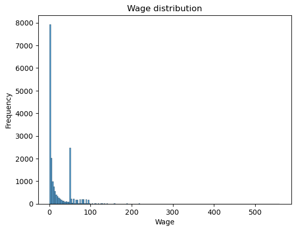

```python
sns.histplot(data['Wage'])
plt.title('Wage distribution')
plt.xlabel('Wage')
plt.ylabel('Frequency')
plt.show()
```

#### Distribution of players value

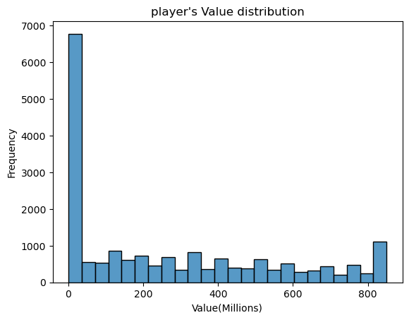

```python
sns.histplot(data['Value'])
plt.title("player's Value distribution")
plt.xlabel('Value(Millions)')
plt.ylabel('Frequency')
plt.show()
```

#### Distribution of players height

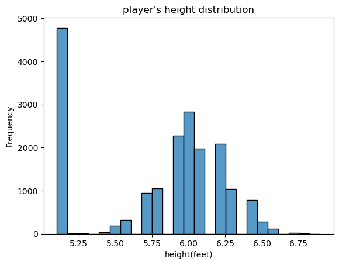

```python
sns.histplot(data['Height'])
plt.title("player's height distribution")
plt.xlabel('height(feet)')
plt.ylabel('Frequency')
plt.show()
```

#### Distribution of player's age

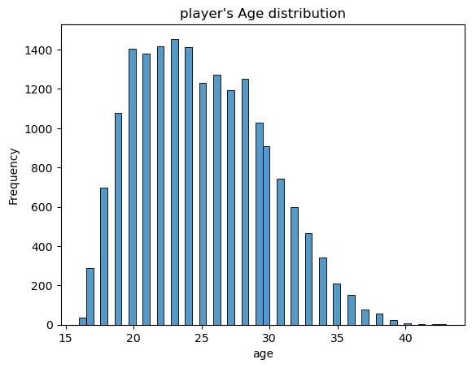

```python
sns.histplot(data['Age'])
plt.title("player's Age distribution")
plt.xlabel('age')
plt.ylabel('Frequency')
plt.show()
```